# STAT2401 Analysis of Experiments

Practical 3

**Aims of this session**

When you complete this session, you will be able to:

1. understand the difference between response and explanatory variables;
2. understand a few different types of bivariate relationships we will be considering in this unit;
3. be able to create scatterplots to explore such bivariate relationships;
4. be able to use correlation analysis to investigate a linear relationship between two (untransformed or transformed) continuous variables;
5. be able to calculate the sample correlation coefficients using Pearson’s, Spearman’s and Kendall’s;
6. be able to perform hypothesis testing related to the population correlation coefficients of Pearson’s, Spearman’s and Kendall’s.

   ```
    - To create a new chunk: Ctrl+Alt+I (Windows), Cmd+Options+I (MacOs)

    - Attempt this practical using this Rmd file, then rename it as your own file (use File then Save As)
   ```

Before you start, load the stored datasets from the LMS *emissions.csv* provided for exercises below as well as other datasets by running the following chunk (assuming the file “Workshop5.Rdata” is saved in the same directory as the .Rmd worksheet).

```
[1] "Anscombe"    "OldFaithful" "wm1"
```

# Question 1 Correlation: Motor vehicle emissions

Motor vehicles must comply with certain emission standards before they can be sold in Australia. The dataset *emissions.xls* contains the results of emissions testing of a sample of 46 vehicles of a particular model.

Columns *CO, HC, NOx* represent the emissions of carbon monoxide, hydrocarbons and oxides of nitrogen respectively, all in g/km. *VN* is a number identifying the particular vehicle being tested.

(a). Use correlation analysis to investigate the relationships between emissions of carbon monoxide, hydrocarbons and oxides of nitrogen for this model vehicle.

```r
emissions = read.csv("emissions.csv", header = TRUE)
View(emissions)
```

There are 46 cars/cases, 3 variables.

We would like to plot all three variables simultaneously.

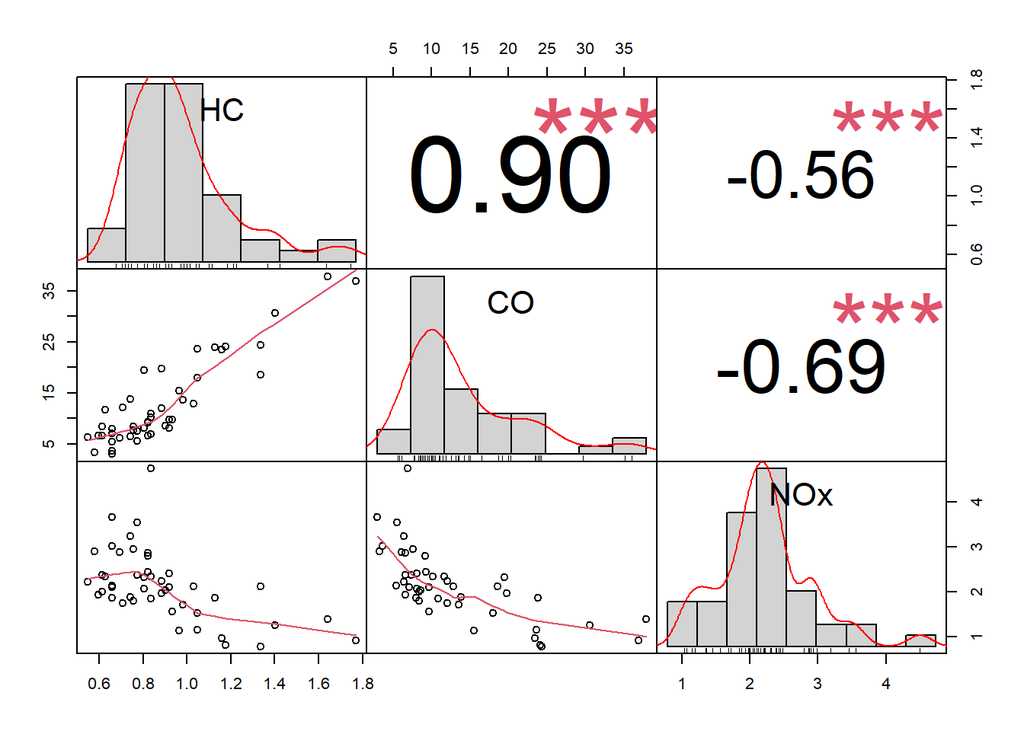

```r
library(PerformanceAnalytics)
chart.Correlation(emissions[, -1], histogram = TRUE, pch = 19)
```

```r
cor(emissions[, -1])  ## you exclude the first column (vehicles)
```

```
            HC         CO        NOx
HC   1.0000000  0.9008276 -0.5588089
CO   0.9008276  1.0000000 -0.6851157
NOx -0.5588089 -0.6851157  1.0000000
```

Selecting all 3 variables tells R to provide correlation coefficients for each possible pair: HC-CO, HC-NOx, CO-NOx.

(b). Describe the relationships between the variables.

The interpretations are as follows:

1. [CO-HC] hydrocarbon emissions show a fairly strong positive correlation with carbon monoxide emissions with a (Pearson’s) correlation coefficient of 0.90. The data points are close to a straight line relationship in the corresponding scatter plot.
2. [NOx-HC] emissions of hydrocarbons and emissions of oxides of nitrogen are negatively correlated. (Pearson’s) correlation coefficient is -0.56. There is more variation including some possible outliers in the scatter plot compared to the CO-HC plot.
3. [NOx-CO] emissions of carbon monoxide and emissions of oxides of nitrogen are also negatively correlated. (Pearson’s) correlation coefficient is -0.69. This correlation is stronger than the NOx-HC relationship but not as strong as the CO-HC relationship. NB In this context, stronger means less scatter, points are closer to lying on the same straight line.

There is also some suggestion of non-linearity in the NOx-HC and NOx-CO relationships.

(c). What difficulty do you think a vehicle manufacturer may have in achieving low emissions for all 3 variables?

The positive correlation suggests that the underlying mechanisms which contribute to high hydrocarbon emissions may also contribute to high carbon monoxide emissions. Therefore many of the measures to reduce hydrocarbon emissions can also be expected to reduce carbon monoxide emissions and vice versa. (Such measures would probably be related to the promotion of complete combustion.)

However, both of these variables are negatively correlated with emissions of oxides of nitrogen so any such measures are likely to increase NOx emissions. Achieving low emissions for all 3 variables is likely to be difficult and require separate strategies.

# Question 2 Scatterplot and Correlations

A geyser is a hot spring in which water boils intermittently, sending a tall column of water and steam into the air. One of the best known geysers in the US is *Old Faithful in Yellowstone National Park, Wyoming.* It was so named when it was first discovered in 1870 because it was (and is) said to erupt regularly. But what does regularly mean?

The data file for this computer lab contains the *R* data frame `faithful`, which consists of sequential measurements of the duration of an eruption (*eruptions*, in minutes) and the time to the next eruption (*waiting*, also in minutes). They were obtained during October 1980 by volunteers. These data were collected so that park rangers could inform tourists when an eruption was likely to occur.

As part of your work with the US National Park Service, you have been tasked with constructing a predictive model for waiting time as a linear function of eruption duration so that park rangers can inform tourists when an eruption is likely to occur.

1. Identify the explanatory and response variables in this case.

Given the objective, to construct a predictive model for *waiting time* as a linear function of *eruption duration* then eruption duration will be used to explain waiting time.

In this case, the variable `eruptions` is the explanatory (on x-axis) and `waiting` is the response (on y-axis).

2. Produce a scatterplot of the waiting time and length of eruptions. (Think about which variable to plot on the y axis and which one to plot on the x axis.)

```r
View(OldFaithful)
head(OldFaithful)
```

```
  eruptions waiting
1     3.600      79
2     1.800      54
3     3.333      74
4     2.283      62
5     4.533      85
6     2.883      55
```

n=272

```r
length(OldFaithful$eruptions)
```

```
[1] 272
```

```r
length(OldFaithful$waiting)
```

```
[1] 272
```

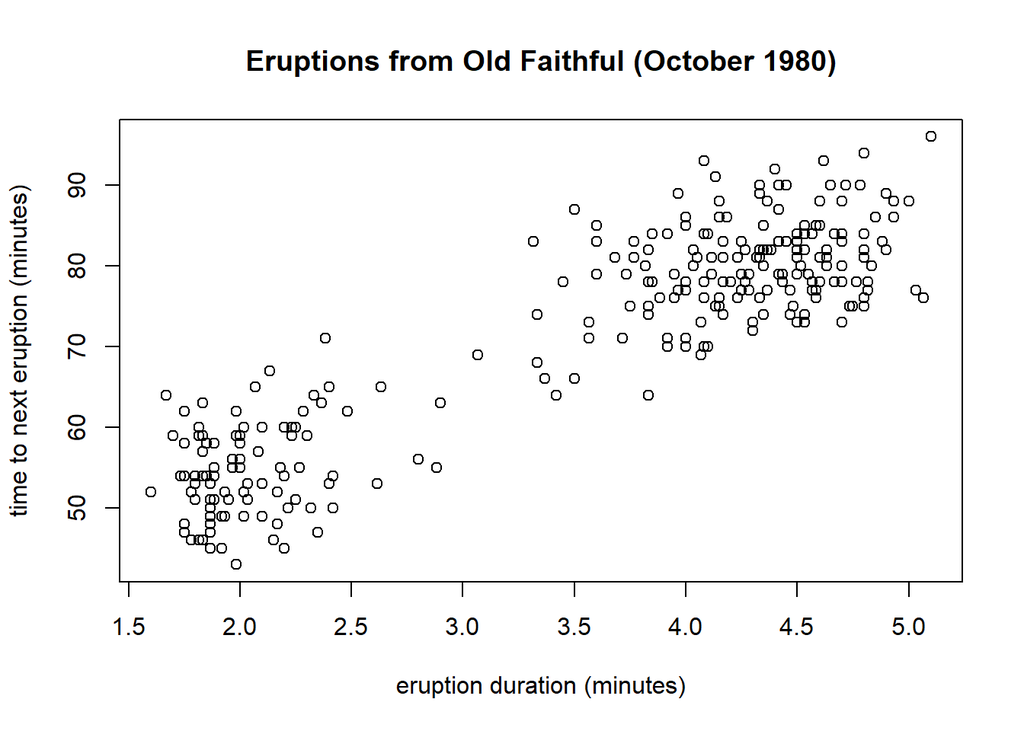

```r
plot(waiting ~ eruptions, data = OldFaithful, xlab = "eruption duration (minutes)",
    ylab = "time to next eruption (minutes)", main = "Eruptions from Old Faithful (October 1980)")
```

```r
Pearson.r <- cor(OldFaithful$eruptions, OldFaithful$waiting)
Spearman.r <- cor(OldFaithful$eruptions, OldFaithful$waiting, method = "spearman")
Kendall.r <- cor(OldFaithful$eruptions, OldFaithful$waiting, method = "kendall")
print(c("Pearson=", Pearson.r, "Spearman=", Spearman.r, "Kendall=", Kendall.r))
```

```
[1] "Pearson="          "0.900811168321813" "Spearman="
[4] "0.777972057651612" "Kendall="          "0.574767353895021"
```

Kendall’s rank correlation is substantially less than both Spearman’s rank and Pearson’s correlation.

Spearman’s rank correlation is substantially less than Pearson’s correlation. This is due to a relative lack of linearity within each of the 2 main data clusters. This becomes very evident if you look here at a plot of the ranks, rather than the raw data:

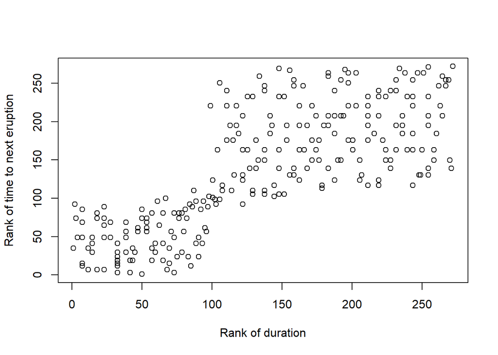

```r
plot(rank(waiting) ~ rank(eruptions), data = OldFaithful, xlab = "Rank of duration",
    ylab = "Rank of time to next eruption")
```

5. Perform hypothesis testing for *positive correlations* using Pearson’s, Spearman’s and Kendall’s correlation coefficients.

```r
cor.test(OldFaithful$eruptions, OldFaithful$waiting, alternative = "greater")
```

```
    Pearson's product-moment correlation

data:  OldFaithful$eruptions and OldFaithful$waiting
t = 34.089, df = 270, p-value < 2.2e-16
alternative hypothesis: true correlation is greater than 0
95 percent confidence interval:
 0.8801013 1.0000000
sample estimates:
      cor
0.9008112
```

```r
cor.test(OldFaithful$eruptions, OldFaithful$waiting, method = "spearman", exact = F,
    alternative = "greater")
```

```
    Spearman's rank correlation rho

data:  OldFaithful$eruptions and OldFaithful$waiting
S = 744659, p-value < 2.2e-16
alternative hypothesis: true rho is greater than 0
sample estimates:
      rho
0.7779721
```

```r
cor.test(OldFaithful$eruptions, OldFaithful$waiting, method = "kendall", alternative = "greater")
```

```
    Kendall's rank correlation tau

data:  OldFaithful$eruptions and OldFaithful$waiting
z = 13.902, p-value < 2.2e-16
alternative hypothesis: true tau is greater than 0
sample estimates:
      tau
0.5747674
```

If we calculate it using the definition of p-value:

```r
pval = pt(34.089, df = 270, lower.tail = F)
pval
```

```
[1] 4.066021e-100
```

5. Decision. As p-value (=4.07e-100) is very small, p-value < 5%, then we reject Ho at 5% significance level
6. We conclude that there is a positive correlation between eruption duration and the time till the next one.

The 6 steps hypothesis testing for *Spearman’s correlation.*

1. $H_0: \rho_s = 0$ (eruption duration and the waiting time are independent) against $H_1:\rho_s > 0$ (eruption duration and the waiting time are dependent)
2. Test statistic. $S=7\times 10^5$
3. The sampling distribution is based on ranks.
4. The p-value < 2.2e-16 (R output)
5. Decision. As p-value (<2e-16) is very small, p-value < 5%, then we reject Ho at 5% significance level
6. We conclude that there is a positive correlation between between eruption duration and the time till the next one.

The 6 steps hypothesis testing for *Kendall’s correlation.*

1. $H_0: \tau = 0$ (eruption duration and the waiting time are independent) against $H_1:\tau > 0$ (eruption duration and the waiting time are positively correlated)
2. Test statistic. $z=14$
3. The sampling distribution is $Z \sim N(0,1)$ approximation.
4. The p-value < 2.2e-16 (R output)
5. Decision. As p-value (<2e-16) is very small, p-value < 5%, then we reject Ho at 5% significance level
6. We conclude that there is a positive correlation between between eruption duration and the time till the next one.